# Data Exploration NES - 2016

Joffrey JOUMAA

October 12, 2022

This document aims at exploring the dataset of 6 individuals in 2016. For that purpose, we need first to load the `weanlingNES` package to load data.

```r
# load library
library(weanlingNES)

# load data
data("data_nes", package = "weanlingNES")
```

Let’s have a look at what’s inside `data_nes$data_2016`:

```r
# list structure
str(data_nes$year_2016, max.level = 1, give.attr = F, no.list = T)
```

```
##  $ ind_3449:Classes 'data.table' and 'data.frame':   384 obs. of  23 variables:
##  $ ind_3450:Classes 'data.table' and 'data.frame':   253 obs. of  23 variables:
##  $ ind_3456:Classes 'data.table' and 'data.frame':   253 obs. of  23 variables:
##  $ ind_3457:Classes 'data.table' and 'data.frame':   253 obs. of  23 variables:
##  $ ind_3460:Classes 'data.table' and 'data.frame':   253 obs. of  23 variables:
##  $ ind_3463:Classes 'data.table' and 'data.frame':   213 obs. of  23 variables:
```

> A list of 6 `data.frames`, one for each seal

For convenience, we aggregate all 6 individuals into one dataset.

```r
# combine all individuals
data_2016 <- rbindlist(data_nes$year_2016, use.name = TRUE, idcol = TRUE)

# display
DT::datatable(data_2016[sample.int(.N, 100), ], options = list(scrollX = T))
```

Table 0.1: Sample of 100 random rows from `data_2016`

|  | .id | rec# | date | time | sunrise | sunset | tflatn_degs | tflats_degs | tfnoonn | tfnoons | sst2_c | sst2depth_dbars | sst2time | tflaterrn | tflaterrs | tflonerrn | tflonerrs | mininttemp_c | maxexttemp_c | maxpress_dbars | latitude_degs | longitude_degs | tflonn_degs | tflons_degs |
| --- | --- | --- | --- | --- | --- | --- | --- | --- | --- | --- | --- | --- | --- | --- | --- | --- | --- | --- | --- | --- | --- | --- | --- | --- |
| 1 | ind_3463 | 144 | 2016-08-29T13:00:00Z | 13:00:00 | 765 | 2130 | 62.381 | 62.381 | 1441 | 1441 | 14.5 | -2.19 | 713 | 23.701 | 23.701 | 29.772 | 29.772 | 4.64 | -20 | 461.31 | 78.57 | 178.28 | 179.91 | 179.91 |
| 2 | ind_3457 | 142 | 2016-08-27T13:00:00Z | 13:00:00 | 465 | 1753 | 61.556 | 61.556 | 1169 | 1169 | 12.86 | -1.56 | 27 | 23.701 | 23.701 | 29.772 | 29.772 | 6.62 | -20 | 146.44 | 77.52 | -96.92 | -111.93 | -111.93 |
| 3 | ind_3457 | 221 | 2016-11-14T13:00:00Z | 13:00:00 | 825 | 2217 | -63.041 | -63.041 | 1553 | 1553 | 14.84 | -0.56 | 153 | 13.407 | 13.407 | 51.566 | 51.566 | 6.66 | -20 | 445.94 | -66.97 | 155.9 | 147.9 | 147.9 |
| 4 | ind_3450 | 46 | 2016-05-23T13:00:00Z | 13:00:00 | 750 | 1673 | 44.715 | 38.61 | 1209 | 1193 | 14.46 | -2.19 | 648 | 17.916 | 19.352 | 14.302 | 11.83 | 5.68 | -20 | 358.81 | 42.01 | -123.67 | -123.04 | -119.04 |
| 5 | ind_3457 | 216 | 2016-11-09T13:00:00Z | 13:00:00 | 447 | 1884 | -63.25 | -63.25 | 1158 | 1158 | 14.48 | -1.06 | 78 | 10.599 | 10.599 | 29.772 | 29.772 | 5.32 | -20 | 530.44 | -68.38 | -115.4 | -113.53 | -113.53 |
| 6 | ind_3456 | 126 | 2016-08-11T13:00:00Z | 13:00:00 | 827 | 2010 | 57.838 | 55.726 | 1317 | 1306 | 15.56 | 0.13 | 663 | 13.407 | 14.628 | 17.189 | 16.307 | 3.96 | -20 | 628.13 | 69.43 | -173.36 | -147.98 | -145.23 |
| 7 | ind_3457 | 145 | 2016-08-30T13:00:00Z | 13:00:00 | 458 | 1718 | 66.429 | 63.998 | 1261 | 1270 | 14.7 | -2.06 | 1034 | 14.628 | 13.978 | 25.783 | 18.231 | 6.18 | -20 | 164.94 | 78.22 | -91.9 | -135.16 | -137.41 |
| 8 | ind_3463 | 112 | 2016-07-28T13:00:00Z | 13:00:00 | 393 | 1752 | 60.258 | 60.258 | 1067 | 1067 | 15.44 | -1.69 | 56 | 18.592 | 18.592 | 51.566 | 51.566 | 4.76 | -20 | 413.81 | 68.03 | -86.5 | -85.12 | -85.12 |
| 9 | ind_3456 | 248 | 2016-12-11T13:00:00Z | 13:00:00 | 226 | 1630 | -64.229 | -64.229 | 950 | 950 | 1290.7 | 32740.13 | 0 | 12.669 | 12.669 |  |  | 21.7 | -20 | 0.63 | -63.11 | -53.62 | -59.12 | -59.12 |
| 10 | ind_3450 | 215 | 2016-11-08T13:00:00Z | 13:00:00 | 389 | 1555 | -67.969 | -67.969 | 905 | 905 | 13.66 | -1.69 | 165 | 5.879 | 5.879 | 36.463 | 36.463 | 5.44 | -20 | 472.31 | -64.51 | -67.05 | -50.3 | -50.3 |

[output cut: 90 more lines]

# 1 Summary

```r
# raw_data
data_2016[, .(
  nb_days_recorded = uniqueN(as.Date(date)),
  max_depth = max(maxpress_dbars),
  sst_mean = mean(sst2_c),
  sst_sd = sd(sst2_c)
), by = .id] %>%
  sable(
    caption = "Summary diving information relative to each 2016 individual",
    digits = 2
  )
```

Table 1.1: Summary diving information relative to each 2016 individual

| .id | nb_days_recorded | max_depth | sst_mean | sst_sd |
| --- | --- | --- | --- | --- |
| ind_3449 | 384 | 1118.81 | 26.54 | 129.91 |
| ind_3450 | 253 | 954.81 | 130.29 | 367.69 |
| ind_3456 | 253 | 697.63 | 125.24 | 360.39 |
| ind_3457 | 253 | 572.94 | 135.56 | 374.71 |
| ind_3460 | 253 | 832.25 | 65.24 | 249.12 |
| ind_3463 | 213 | 648.81 | 212.19 | 462.88 |

Well, it seems that `sst` is a bit odd. Let’s have a look at its distribution.

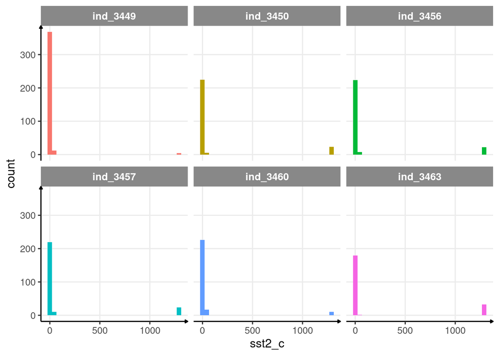

```r
ggplot(data_2016, aes(x = sst2_c, fill = .id)) +
  geom_histogram(show.legend = FALSE) +
  facet_wrap(.id ~ .) +
  theme_jjo()
```

Let’s remove any data with a `sst2_c` > 500.

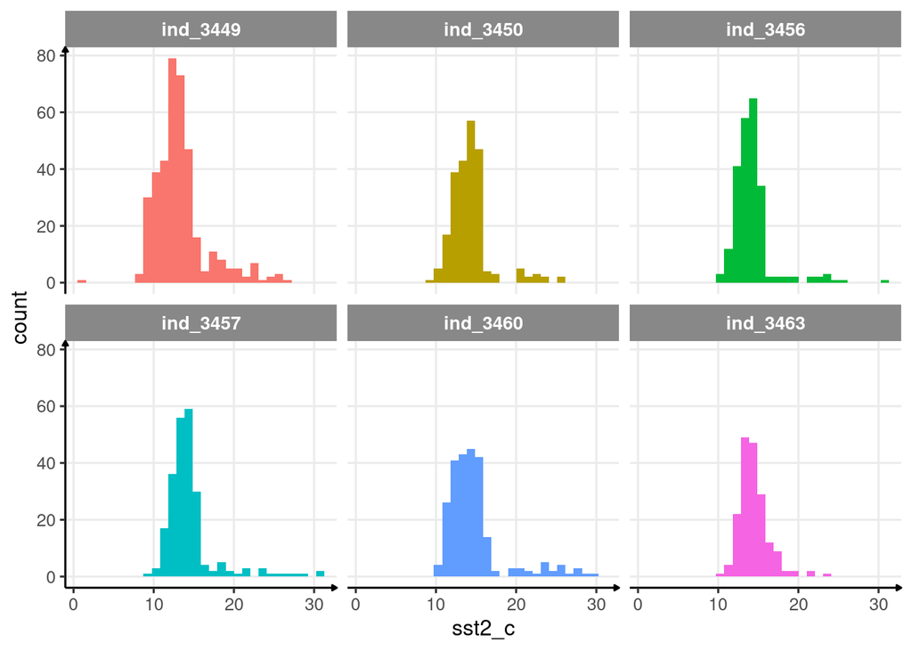

```r
data_2016_filter <- data_2016[sst2_c < 500, ]
ggplot(data_2016_filter, aes(x = sst2_c, fill = .id)) +
  geom_histogram(show.legend = FALSE) +
  facet_wrap(.id ~ .) +
  theme_jjo()
```

Well, that seems to be much better! In the process of filtering out odd values, we removed 116 rows this way:

```r
# nbrow removed
data_2016[sst2_c > 500, .(nb_row_removed = .N), by = .id] %>%
  sable(caption = "# of rows removed by 2016-individuals")
```

Table 1.2: # of rows removed by 2016-individuals

| .id | nb_row_removed |
| --- | --- |
| ind_3449 | 4 |
| ind_3450 | 23 |
| ind_3456 | 22 |
| ind_3457 | 24 |
| ind_3460 | 10 |
| ind_3463 | 33 |

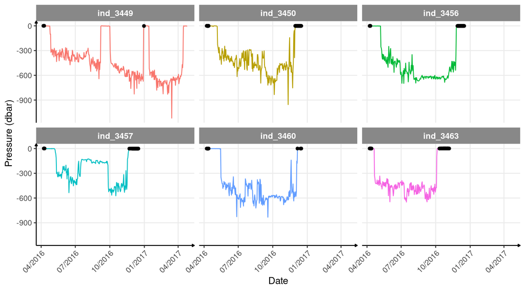

Figure 1.3: Where and when the `sst2` outliers occured

```r
# max depth
ggplot(
  data_2016,
  aes(y = -maxpress_dbars, x = as.Date(date), col = .id)
) +
  geom_path(show.legend = FALSE) +
  geom_point(data = data_2016[sst2_c > 500, ], col = "black") +
  scale_x_date(date_labels = "%m/%Y") +
  labs(y = "Pressure (dbar)", x = "Date") +
  facet_wrap(.id ~ .) +
  theme_jjo() +
  theme(axis.text.x = element_text(angle = 45, hjust = 1))
```

Well this latter plot highlights several points:

- most of the outliers occur while animals spend the whole day at the surface (or on the ground), probably resting, so essentially at the beginning and the end of each track
- we can already see that `ind_3449` seems to have return ashore twice during his track

Let’s see if we can double check that, using a map.

```r
# interactive map
# htmltools::tagList(list(
  leaflet() %>%
    setView(lng = -122, lat = 38, zoom = 2) %>%
    addTiles() %>%
    addPolylines(
      lat = data_2016[.id == "ind_3449", latitude_degs],
      lng = data_2016[.id == "ind_3449", longitude_degs],
      weight = 2
    ) %>%
    addCircleMarkers(
      lat = data_2016[.id == "ind_3449" & sst2_c > 500, latitude_degs],
      lng = data_2016[.id == "ind_3449" &
                        sst2_c > 500, longitude_degs],
      radius = 3,
      stroke = FALSE,
      color = "red",
      fillOpacity = 1
    )
```

[interactive chart not shown]

Figure 1.4: It is supposed to be the track of `ind_3449`… (red dots are the location of removed rows)

```r
# ))
```

… these coordinates seem weird !

```r
# summary of the coordinates by individuals
data_2016[, .(.id, longitude_degs, latitude_degs)] %>%
  tbl_summary(by = .id) %>%
  modify_caption("Summary of `longitude_degree` and `latitude_degree`")
```

Table 1.3: Summary of `longitude_degree` and `latitude_degree`

| **Characteristic** | **ind_3449**, N = 384<sup>1</sup> | **ind_3450**, N = 253<sup>1</sup> | **ind_3456**, N = 253<sup>1</sup> | **ind_3457**, N = 253<sup>1</sup> | **ind_3460**, N = 253<sup>1</sup> | **ind_3463**, N = 213<sup>1</sup> |
| --- | --- | --- | --- | --- | --- | --- |
| longitude_degs | -119 (-132, -69) | -124 (-144, -99) | -112 (-134, -6) | -122 (-132, -97) | -122 (-144, -85) | -121 (-134, -93) |
| latitude_degs | 39 (-67, 68) | 60 (-63, 68) | 56 (-63, 68) | 44 (-63, 68) | 59 (-63, 68) | 63 (42, 72) |

<sup>1</sup> Median (IQR)

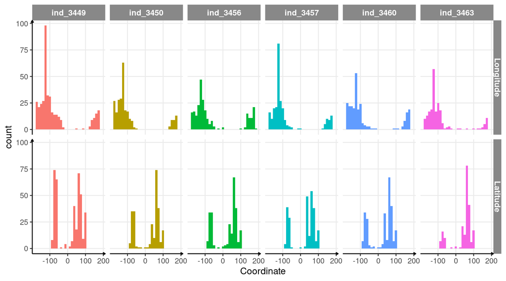

Figure 1.5: Distribution of coordinates per seal

```r
# distribution coordinates
ggplot(
  data = melt(data_2016[, .(
    Longitude = longitude_degs,
    Latitude = latitude_degs,
    .id
  )],
  id.vars =
    ".id", value.name = "Coordinate"
  ),
  aes(x = Coordinate, fill = .id)
) +
  geom_histogram(show.legend = F) +
  facet_grid(variable ~ .id) +
  theme_jjo()
```

- For `longitude` a part of the data seems to have a wrong sign, resulting in these distribution, that appear to be cut off
- For `latitude`, well this is ensure but maybe the same problem occurs

Let’s try to play on coordinates’ sign to see if we can display something that makes more sense.

```r
# interactive map
htmltools::tagList(list(
  leaflet() %>%
    setView(lng = -122, lat = 50, zoom = 3) %>%
    addTiles() %>%
    addPolylines(
      lat = data_2016[.id == "ind_3449", abs(latitude_degs)],
      lng = data_2016[.id == "ind_3449",-abs(longitude_degs)],
      weight = 2
    )
))
```

[interactive chart not shown]

> I’ll better ask Roxanne!

# 2 Missing values

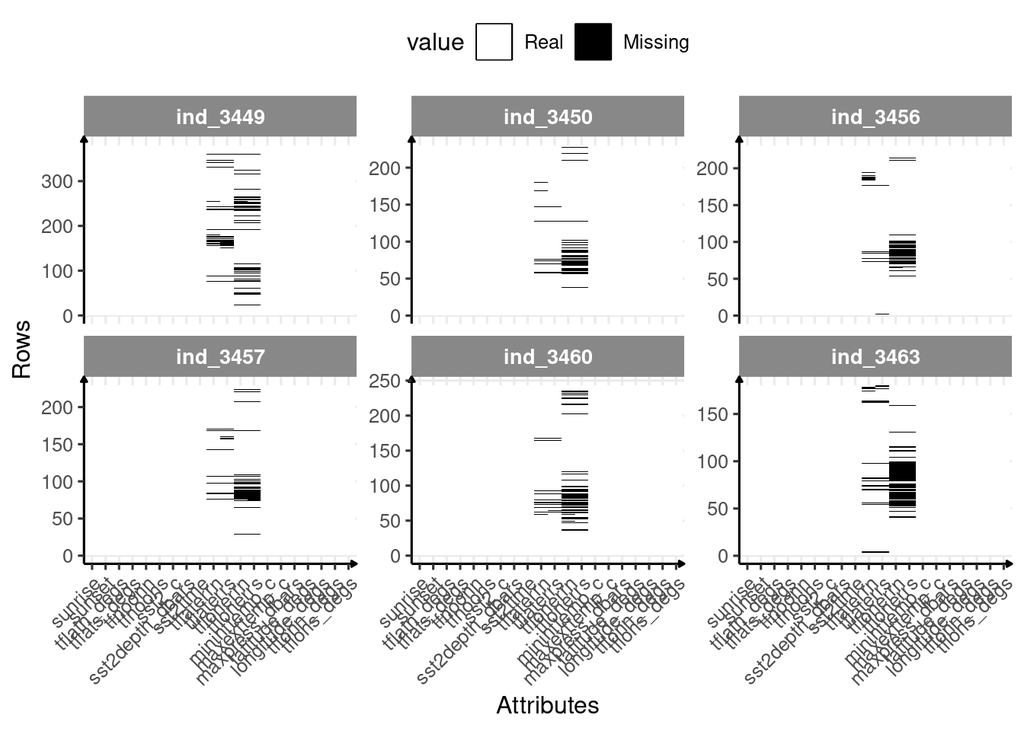

Figure 2.1: Check for missing value in 2016-individuals

```r
# build dataset to check for missing values
dataPlot <- melt(data_2016_filter[, .(.id, is.na(.SD)), .SDcol = -c(
  ".id",
  "rec#",
  "date",
  "time"
)])
# add the id of rows
dataPlot[, id_row := c(1:.N), by = c("variable", ".id")]

# plot
ggplot(dataPlot, aes(x = variable, y = id_row, fill = value)) +
  geom_tile() +
  labs(x = "Attributes", y = "Rows") +
  scale_fill_manual(
    values = c("white", "black"),
    labels = c("Real", "Missing")
  ) +
  facet_wrap(.id ~ ., scales = "free_y") +
  theme_jjo() +
  theme(
    legend.position = "top",
    axis.text.x = element_text(angle = 45, hjust = 1),
    legend.key = element_rect(colour = "black")
  )
```